# ABC Meta-Analysis: Why Convergence Stalls and How to Fix It

# 3. Full ABC Run (10 Generations, 100 Particles)

```r
# Simplified ABC-SMC implementation for analysis
# (We replicate the logic from smc_abc.R but log everything)

PARAMS_ABC <- list(
  list(name = "p_local_dup",   lo = -5,   hi = -3,   transform = function(x) 10^x),
  list(name = "p_distal_dup",  lo = -2,   hi = -0.3, transform = function(x) 10^x),
  list(name = "p_del_chunk",   lo = -6,   hi = -4,   transform = function(x) 10^x),
  list(name = "local_shape",   lo = 0.5,  hi = 5,    transform = function(x) x),
  list(name = "local_scale",   lo = 1,    hi = 50,   transform = function(x) x),
  list(name = "distal_shape",  lo = 0.5,  hi = 5,    transform = function(x) x),
  list(name = "distal_scale",  lo = 10,   hi = 2000, transform = function(x) x),
  list(name = "del_shape",     lo = 0.5,  hi = 5,    transform = function(x) x),
  list(name = "del_scale",     lo = 1,    hi = 50,   transform = function(x) x)
)
pnames <- sapply(PARAMS_ABC, `[[`, "name")

compute_distance_local <- function(stats, target, stat_scales = NULL) {
  diffs <- c(
    med_near   = stats$med_near  - target$med_near,
    med_far    = stats$med_far   - target$med_far,
    near_frac  = stats$near_frac - target$near_frac,
    mean_load  = (stats$mean_load - target$mean_load) / max(target$mean_load, 0.1),
    array_size = (log10(stats$n_units) - log10(target$target_array_size))
  )
  if (!is.null(stat_scales)) diffs <- diffs / stat_scales
  0.5 * sqrt(mean(diffs^2)) + 0.5 * max(abs(diffs))
}

sample_prior_abc <- function() {
  row <- as.list(sapply(PARAMS_ABC, function(p) runif(1, p$lo, p$hi)))
  names(row) <- pnames
  as.data.table(row)
}

perturb_abc <- function(particle, sds) {
  new <- copy(particle)
  for (j in seq_along(PARAMS_ABC)) {
    pn <- PARAMS_ABC[[j]]$name
    new[[pn]] <- new[[pn]] + rnorm(1, 0, sds[[pn]])
  }
  for (pn in c("local_shape", "distal_shape", "del_shape"))
    new[[pn]] <- max(0.01, new[[pn]])
  for (pn in c("local_scale", "distal_scale", "del_scale"))
    new[[pn]] <- max(0.1, new[[pn]])
  new
}

compute_sds_abc <- function(kept) {
  sds <- list()
  for (j in seq_along(PARAMS_ABC)) {
    pn <- PARAMS_ABC[[j]]$name
    rng <- PARAMS_ABC[[j]]$hi - PARAMS_ABC[[j]]$lo
    emp <- if (!is.null(kept) && nrow(kept) >= 3) sd(kept[[pn]], na.rm=T) else NA
    sds[[pn]] <- if (is.na(emp) || emp < 1e-10) 0.3 * rng else min(2 * emp, rng * 0.15)
  }
  sds
}

run_sim_from_row <- function(row) {
  params <- list(
    p_local_dup  = PARAMS_ABC[[1]]$transform(row$p_local_dup),
    p_distal_dup = PARAMS_ABC[[2]]$transform(row$p_distal_dup),
    p_del_chunk  = PARAMS_ABC[[3]]$transform(row$p_del_chunk),
    local_shape  = row$local_shape,
    local_scale  = row$local_scale,
    distal_shape = row$distal_shape,
    distal_scale = row$distal_scale,
    del_shape    = row$del_shape,
    del_scale    = row$del_scale
  )
  run_one(params, timeout = 30)
}

# --- Run ABC ---
N_PARTICLES <- 100
MAX_GEN <- 10
RETENTION <- 0.3

abc_log <- list()  # store all generations
convergence_abc <- data.table()

stat_scales <- NULL
kept <- NULL

for (gen in 0:MAX_GEN) {
  cat(sprintf("\n=== ABC Generation %d ===\n", gen))
  t_gen <- proc.time()[3]

  particles <- NULL
  n_filled <- 0
  n_failed <- 0
  n_attempts <- 0
  max_attempts <- N_PARTICLES * 5

  for (att in seq_len(max_attempts)) {
    if (n_filled >= N_PARTICLES) break
    n_attempts <- n_attempts + 1

    if (gen == 0) {
      proposed <- sample_prior_abc()
    } else {
      parent <- kept[sample.int(nrow(kept), 1), ..pnames]
      proposed <- perturb_abc(parent, compute_sds_abc(kept))
    }

    res <- run_sim_from_row(proposed)

    if (res$status != "ok" || is.na(res$med_near) || is.na(res$med_far)) {
      n_failed <- n_failed + 1
      next
    }

    d <- compute_distance_local(res, TARGET, stat_scales)
    row <- cbind(proposed, res, data.table(distance = d))
    if (is.null(particles)) particles <- row
    else particles <- rbind(particles, row, fill = TRUE)
    n_filled <- n_filled + 1

    if (n_filled %% 20 == 0)
      cat(sprintf("  filled %d/%d (attempts: %d)\n", n_filled, N_PARTICLES, n_attempts))
  }

  gen_elapsed <- proc.time()[3] - t_gen

  if (is.null(particles) || nrow(particles) < 3) {
    cat("  Not enough particles, stopping\n")
    break
  }

  # After Gen 0: compute stat scales
  if (gen == 0 && is.null(stat_scales)) {
    rel_load <- (particles$mean_load - TARGET$mean_load) / max(TARGET$mean_load, 0.1)
    rel_size <- log10(particles$n_units) - log10(TARGET$target_array_size)
    stat_scales <- c(
      med_near = sd(particles$med_near, na.rm=T),
      med_far = sd(particles$med_far, na.rm=T),
      near_frac = sd(particles$near_frac, na.rm=T),
      mean_load = sd(rel_load, na.rm=T),
      array_size = sd(rel_size, na.rm=T)
    )
    stat_scales[is.na(stat_scales) | stat_scales < 1e-10] <- 1

    # Recompute distances with scales
    for (ri in seq_len(nrow(particles))) {
      particles[ri, distance := compute_distance_local(
        .SD, TARGET, stat_scales),
        .SDcols = c("med_near", "med_far", "near_frac", "mean_load", "n_units")]
    }
  }

  abc_log[[gen + 1]] <- copy(particles)

  convergence_abc <- rbind(convergence_abc, data.table(
    gen = gen,
    best = min(particles$distance),
    median = median(particles$distance),
    n_particles = nrow(particles),
    n_failed = n_failed,
    n_attempts = n_attempts,
    failure_rate = round(n_failed / n_attempts, 2),
    elapsed = round(gen_elapsed)
  ))

  # Selection
  particles <- particles[order(distance)]
  n_keep <- max(3L, as.integer(nrow(particles) * RETENTION))
  kept <- particles[seq_len(min(n_keep, nrow(particles)))]

  cat(sprintf("  Gen %d: %d particles, best=%.3f, median=%.3f, failures=%d/%d (%.0f%%), time=%.0fs\n",
              gen, nrow(particles), min(particles$distance),
              median(particles$distance), n_failed, n_attempts,
              100 * n_failed / n_attempts, gen_elapsed))
}
```

```
#>
#> === ABC Generation 0 ===
#>   filled 20/100 (attempts: 124)
#>   filled 40/100 (attempts: 220)
#>   filled 60/100 (attempts: 342)
#>   filled 80/100 (attempts: 457)
#>   Gen 0: 86 particles, best=0.322, median=1.459, failures=414/500 (83%), time=462s
#>
#> === ABC Generation 1 ===
#>   filled 20/100 (attempts: 39)
#>   filled 40/100 (attempts: 85)
#>   filled 60/100 (attempts: 118)
#>   filled 80/100 (attempts: 153)
#>   filled 100/100 (attempts: 194)
#>   Gen 1: 100 particles, best=0.536, median=1.516, failures=94/194 (48%), time=259s
#>
#> === ABC Generation 2 ===
#>   filled 20/100 (attempts: 45)
#>   filled 40/100 (attempts: 73)
#>   filled 60/100 (attempts: 110)
#>   filled 80/100 (attempts: 157)
#>   filled 100/100 (attempts: 201)
#>   Gen 2: 100 particles, best=0.618, median=1.499, failures=101/201 (50%), time=251s
#>
#> === ABC Generation 3 ===
#>   filled 20/100 (attempts: 40)
#>   filled 40/100 (attempts: 86)
#>   filled 60/100 (attempts: 118)
#>   filled 80/100 (attempts: 149)
#>   filled 100/100 (attempts: 181)
#>   Gen 3: 100 particles, best=0.325, median=1.376, failures=81/181 (45%), time=178s
#>
#> === ABC Generation 4 ===
#>   filled 20/100 (attempts: 43)
#>   filled 40/100 (attempts: 78)
#>   filled 60/100 (attempts: 122)
#>   filled 80/100 (attempts: 163)
#>   filled 100/100 (attempts: 206)
#>   Gen 4: 100 particles, best=0.567, median=1.344, failures=106/206 (51%), time=190s
#>
```

[output cut: 32 more lines]

```
#> === ABC Generation 9 ===
#>   filled 20/100 (attempts: 49)
#>   filled 40/100 (attempts: 92)
#>   filled 60/100 (attempts: 131)
#>   filled 80/100 (attempts: 167)
#>   filled 100/100 (attempts: 208)
#>   Gen 9: 100 particles, best=0.381, median=1.391, failures=108/208 (52%), time=145s
#>
#> === ABC Generation 10 ===
#>   filled 20/100 (attempts: 29)
#>   filled 40/100 (attempts: 63)
#>   filled 60/100 (attempts: 105)
#>   filled 80/100 (attempts: 136)
#>   filled 100/100 (attempts: 165)
#>   Gen 10: 100 particles, best=0.436, median=1.326, failures=65/165 (39%), time=107s
```

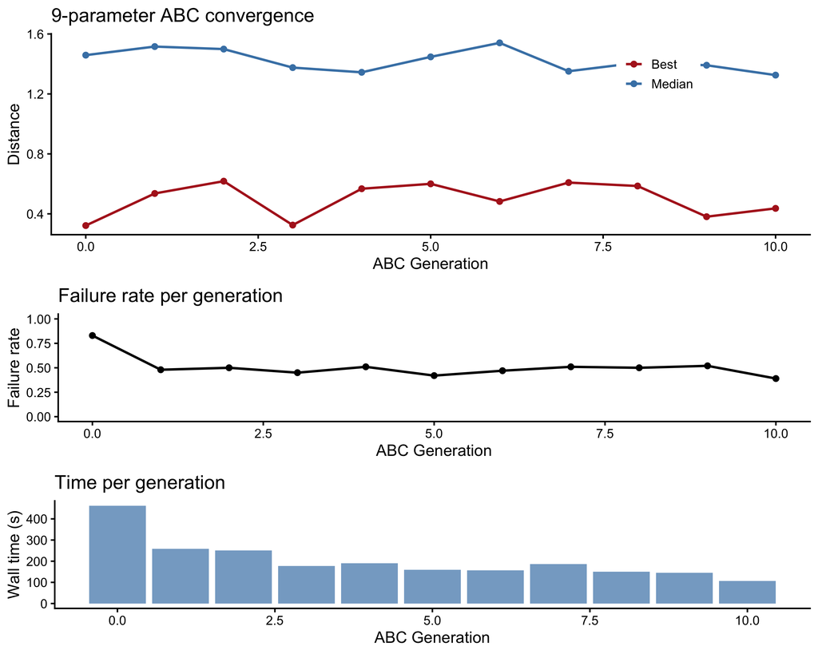

```r
# Convergence plot
p_conv <- ggplot(convergence_abc, aes(x = gen)) +
  geom_line(aes(y = median, color = "Median"), linewidth = 1) +
  geom_point(aes(y = median, color = "Median"), size = 2) +
  geom_line(aes(y = best, color = "Best"), linewidth = 1) +
  geom_point(aes(y = best, color = "Best"), size = 2) +
  scale_color_manual(values = c("Median" = "steelblue", "Best" = "firebrick")) +
  theme_classic(base_size = 14) +
  labs(x = "ABC Generation", y = "Distance", color = NULL,
       title = "9-parameter ABC convergence") +
  theme(legend.position = c(0.8, 0.8))

p_fail_rate <- ggplot(convergence_abc, aes(x = gen, y = failure_rate)) +
  geom_line(linewidth = 1) + geom_point(size = 2) +
  theme_classic(base_size = 14) +
  labs(x = "ABC Generation", y = "Failure rate",
       title = "Failure rate per generation") +
  ylim(0, 1)

p_timing <- ggplot(convergence_abc, aes(x = gen, y = elapsed)) +
  geom_bar(stat = "identity", fill = "steelblue", alpha = 0.7) +
  theme_classic(base_size = 14) +
  labs(x = "ABC Generation", y = "Wall time (s)",
       title = "Time per generation")

plot_grid(p_conv, p_fail_rate, p_timing, ncol = 1, rel_heights = c(1.2, 0.8, 0.8))
```

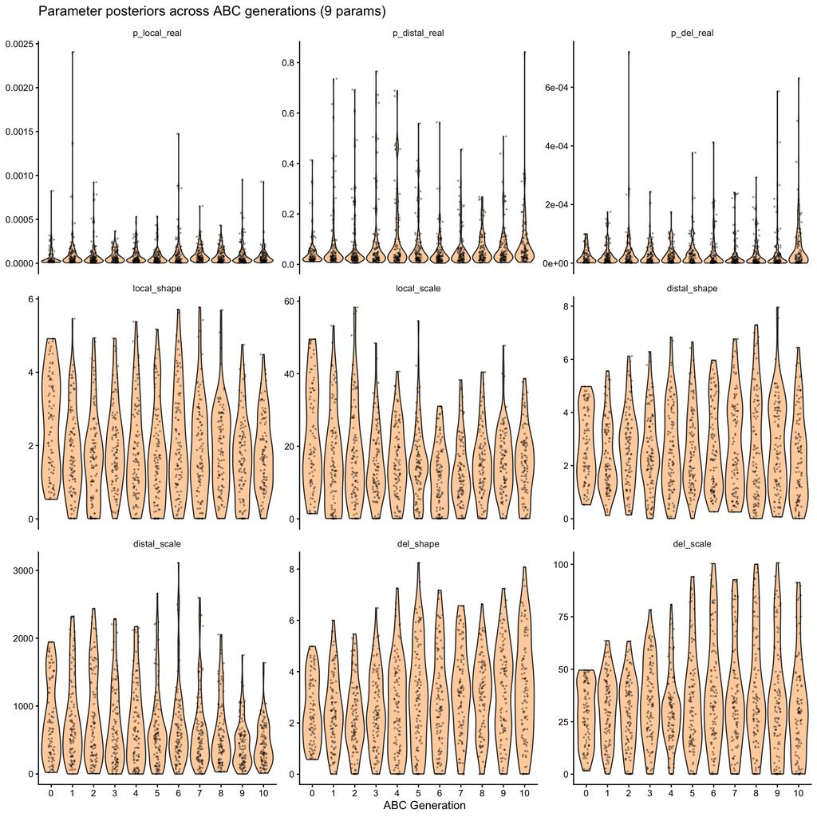

```r
# Parameter evolution across ABC generations
if (length(abc_log) > 0) {
  gen_dt <- rbindlist(lapply(seq_along(abc_log), function(i) {
    d <- copy(abc_log[[i]])
    d[, gen := i - 1L]
    d
  }), fill = TRUE)

  # Transform rates
  gen_dt[, p_local_real := 10^p_local_dup]
  gen_dt[, p_distal_real := 10^p_distal_dup]
  gen_dt[, p_del_real := 10^p_del_chunk]

  rate_melt <- melt(gen_dt,
    id.vars = c("gen", "distance"),
    measure.vars = c("p_local_real", "p_distal_real", "p_del_real",
                     "local_shape", "local_scale", "distal_shape",
                     "distal_scale", "del_shape", "del_scale"),
    variable.name = "param", value.name = "value")
  rate_melt[, gen_f := factor(gen)]

  ggplot(rate_melt, aes(x = gen_f, y = value)) +
    geom_violin(fill = "darkorange", alpha = 0.4, scale = "width") +
    geom_jitter(width = 0.15, size = 0.3, alpha = 0.3) +
    facet_wrap(~ param, scales = "free_y", ncol = 3) +
    theme_classic(base_size = 10) +
    theme(strip.background = element_blank()) +
    labs(x = "ABC Generation", y = NULL,
         title = "Parameter posteriors across ABC generations (9 params)")
}
```

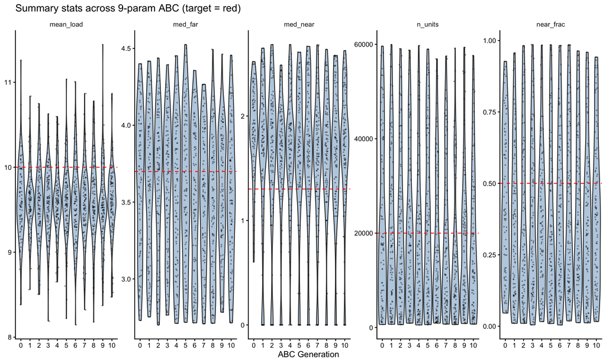

```r
if (length(abc_log) > 0) {
  stat_melt <- melt(gen_dt,
    id.vars = "gen",
    measure.vars = c("n_units", "mean_load", "med_near", "med_far", "near_frac"),
    variable.name = "stat", value.name = "value")
  stat_melt[, gen_f := factor(gen)]

  target_lines <- data.table(
    stat = c("n_units", "mean_load", "med_near", "med_far", "near_frac"),
    target = c(TARGET$target_array_size, TARGET$mean_load,
               TARGET$med_near, TARGET$med_far, TARGET$near_frac)
  )

  ggplot(stat_melt, aes(x = gen_f, y = value)) +
    geom_violin(fill = "steelblue", alpha = 0.4, scale = "width") +
    geom_jitter(width = 0.15, size = 0.3, alpha = 0.3) +
    geom_hline(data = target_lines, aes(yintercept = target),
               color = "red", linetype = "dashed") +
    facet_wrap(~ stat, scales = "free_y", ncol = 5) +
    theme_classic(base_size = 10) +
    theme(strip.background = element_blank()) +
    labs(x = "ABC Generation", y = NULL,
         title = "Summary stats across 9-param ABC (target = red)")
}
```

# 4. Alternative Approaches

## 4.1 Three-Parameter ABC (Fix Chunk Sizes)

Fix all 6 chunk-size parameters at baseline values and only infer the 3 rates.

```r
PARAMS_3 <- list(
  list(name = "p_local_dup",   lo = -5,   hi = -3,   transform = function(x) 10^x),
  list(name = "p_distal_dup",  lo = -2,   hi = -0.3, transform = function(x) 10^x),
  list(name = "p_del_chunk",   lo = -6,   hi = -4,   transform = function(x) 10^x)
)
pnames_3 <- sapply(PARAMS_3, `[[`, "name")

run_sim_3param <- function(row) {
  params <- BASELINE
  params$p_local_dup  <- 10^row$p_local_dup
  params$p_distal_dup <- 10^row$p_distal_dup
  params$p_del_chunk  <- 10^row$p_del_chunk
  run_one(params, timeout = 30)
}

perturb_3 <- function(particle, sds) {
  new <- copy(particle)
  for (j in seq_along(PARAMS_3)) {
    pn <- PARAMS_3[[j]]$name
    new[[pn]] <- new[[pn]] + rnorm(1, 0, sds[[pn]])
  }
  new
}

compute_sds_3 <- function(kept) {
  sds <- list()
  for (j in seq_along(PARAMS_3)) {
    pn <- PARAMS_3[[j]]$name
    rng <- PARAMS_3[[j]]$hi - PARAMS_3[[j]]$lo
    emp <- if (!is.null(kept) && nrow(kept) >= 3) sd(kept[[pn]], na.rm=T) else NA
    sds[[pn]] <- if (is.na(emp) || emp < 1e-10) 0.3 * rng else min(2 * emp, rng * 0.15)
  }
  sds
}

abc3_log <- list()
convergence_3 <- data.table()
stat_scales_3 <- NULL
kept_3 <- NULL

for (gen in 0:MAX_GEN) {
  cat(sprintf("\n=== 3-param ABC Gen %d ===\n", gen))
  t_gen <- proc.time()[3]

  particles <- NULL
  n_filled <- 0; n_failed <- 0; n_attempts <- 0
  max_att <- N_PARTICLES * 5

  for (att in seq_len(max_att)) {
    if (n_filled >= N_PARTICLES) break
    n_attempts <- n_attempts + 1

    if (gen == 0) {
      proposed <- as.data.table(as.list(
        sapply(PARAMS_3, function(p) runif(1, p$lo, p$hi))
      ))
      names(proposed) <- pnames_3
    } else {
      parent <- kept_3[sample.int(nrow(kept_3), 1), ..pnames_3]
      proposed <- perturb_3(parent, compute_sds_3(kept_3))
    }

    res <- run_sim_3param(proposed)
    if (res$status != "ok" || is.na(res$med_near) || is.na(res$med_far)) {
      n_failed <- n_failed + 1
      next
    }

    d <- compute_distance_local(res, TARGET, stat_scales_3)
    row <- cbind(proposed, res, data.table(distance = d))
    if (is.null(particles)) particles <- row
    else particles <- rbind(particles, row, fill = TRUE)
    n_filled <- n_filled + 1
  }

  gen_elapsed <- proc.time()[3] - t_gen
  if (is.null(particles) || nrow(particles) < 3) break

  if (gen == 0 && is.null(stat_scales_3)) {
    rel_load <- (particles$mean_load - TARGET$mean_load) / max(TARGET$mean_load, 0.1)
    rel_size <- log10(particles$n_units) - log10(TARGET$target_array_size)
    stat_scales_3 <- c(
      med_near = sd(particles$med_near, na.rm=T),
      med_far = sd(particles$med_far, na.rm=T),
      near_frac = sd(particles$near_frac, na.rm=T),
      mean_load = sd(rel_load, na.rm=T),
      array_size = sd(rel_size, na.rm=T)
    )
    stat_scales_3[is.na(stat_scales_3) | stat_scales_3 < 1e-10] <- 1
    for (ri in seq_len(nrow(particles))) {
      particles[ri, distance := compute_distance_local(
        .SD, TARGET, stat_scales_3),
        .SDcols = c("med_near", "med_far", "near_frac", "mean_load", "n_units")]
    }
  }

  abc3_log[[gen + 1]] <- copy(particles)
  convergence_3 <- rbind(convergence_3, data.table(
    gen = gen, best = min(particles$distance),
    median = median(particles$distance),
    n_particles = nrow(particles), n_failed = n_failed,
    n_attempts = n_attempts,
    failure_rate = round(n_failed / n_attempts, 2),
    elapsed = round(gen_elapsed)
  ))

  particles <- particles[order(distance)]
  n_keep <- max(3L, as.integer(nrow(particles) * RETENTION))
  kept_3 <- particles[seq_len(min(n_keep, nrow(particles)))]

  cat(sprintf("  3p Gen %d: best=%.3f, median=%.3f, fail=%.0f%%, time=%.0fs\n",
              gen, min(particles$distance), median(particles$distance),
              100 * n_failed / n_attempts, gen_elapsed))
}
```

```
#>
#> === 3-param ABC Gen 0 ===
#>   3p Gen 0: best=0.980, median=1.590, fail=70%, time=312s
#>
#> === 3-param ABC Gen 1 ===
#>   3p Gen 1: best=1.016, median=1.536, fail=36%, time=112s
#>
#> === 3-param ABC Gen 2 ===
#>   3p Gen 2: best=1.027, median=1.584, fail=27%, time=106s
#>
#> === 3-param ABC Gen 3 ===
#>   3p Gen 3: best=1.064, median=1.575, fail=35%, time=137s
#>
#> === 3-param ABC Gen 4 ===
#>   3p Gen 4: best=1.037, median=1.514, fail=29%, time=116s
#>
#> === 3-param ABC Gen 5 ===
#>   3p Gen 5: best=0.986, median=1.568, fail=31%, time=132s
#>
#> === 3-param ABC Gen 6 ===
#>   3p Gen 6: best=1.036, median=1.527, fail=21%, time=113s
#>
#> === 3-param ABC Gen 7 ===
#>   3p Gen 7: best=0.816, median=1.542, fail=36%, time=172s
#>
#> === 3-param ABC Gen 8 ===
#>   3p Gen 8: best=0.937, median=1.576, fail=23%, time=102s
#>
#> === 3-param ABC Gen 9 ===
#>   3p Gen 9: best=0.976, median=1.647, fail=31%, time=108s
#>
#> === 3-param ABC Gen 10 ===
#>   3p Gen 10: best=1.016, median=1.530, fail=30%, time=109s
```

## 4.2 Tight Prior ABC (9 params, narrow range)

Use a much tighter prior centered on vignette values.

```r
PARAMS_TIGHT <- list(
  list(name = "p_local_dup",   lo = -4.0,  hi = -3.0,  transform = function(x) 10^x),
  list(name = "p_distal_dup",  lo = -1.8,  hi = -0.8,  transform = function(x) 10^x),
  list(name = "p_del_chunk",   lo = -5.0,  hi = -3.5,  transform = function(x) 10^x),
  list(name = "local_shape",   lo = 1.0,   hi = 4.0,   transform = function(x) x),
  list(name = "local_scale",   lo = 5,     hi = 30,    transform = function(x) x),
  list(name = "distal_shape",  lo = 1.0,   hi = 4.0,   transform = function(x) x),
  list(name = "distal_scale",  lo = 100,   hi = 1000,  transform = function(x) x),
  list(name = "del_shape",     lo = 1.0,   hi = 4.0,   transform = function(x) x),
  list(name = "del_scale",     lo = 5,     hi = 30,    transform = function(x) x)
)
pnames_t <- sapply(PARAMS_TIGHT, `[[`, "name")

perturb_tight <- function(particle, sds) {
  new <- copy(particle)
  for (j in seq_along(PARAMS_TIGHT)) {
    pn <- PARAMS_TIGHT[[j]]$name
    new[[pn]] <- new[[pn]] + rnorm(1, 0, sds[[pn]])
  }
  for (pn in c("local_shape", "distal_shape", "del_shape"))
    new[[pn]] <- max(0.01, new[[pn]])
  for (pn in c("local_scale", "distal_scale", "del_scale"))
    new[[pn]] <- max(0.1, new[[pn]])
  new
}

compute_sds_tight <- function(kept) {
  sds <- list()
  for (j in seq_along(PARAMS_TIGHT)) {
    pn <- PARAMS_TIGHT[[j]]$name
    rng <- PARAMS_TIGHT[[j]]$hi - PARAMS_TIGHT[[j]]$lo
    emp <- if (!is.null(kept) && nrow(kept) >= 3) sd(kept[[pn]], na.rm=T) else NA
    sds[[pn]] <- if (is.na(emp) || emp < 1e-10) 0.3 * rng else min(2 * emp, rng * 0.15)
  }
  sds
}

run_sim_tight <- function(row) {
  params <- list(
    p_local_dup  = 10^row$p_local_dup,
    p_distal_dup = 10^row$p_distal_dup,
    p_del_chunk  = 10^row$p_del_chunk,
    local_shape  = row$local_shape,
    local_scale  = row$local_scale,
    distal_shape = row$distal_shape,
    distal_scale = row$distal_scale,
    del_shape    = row$del_shape,
    del_scale    = row$del_scale
  )
  run_one(params, timeout = 30)
}

abc_tight_log <- list()
convergence_tight <- data.table()
stat_scales_tight <- NULL
kept_tight <- NULL

for (gen in 0:MAX_GEN) {
  cat(sprintf("\n=== Tight ABC Gen %d ===\n", gen))
  t_gen <- proc.time()[3]

  particles <- NULL
  n_filled <- 0; n_failed <- 0; n_attempts <- 0

  for (att in seq_len(N_PARTICLES * 5)) {
    if (n_filled >= N_PARTICLES) break
    n_attempts <- n_attempts + 1

    if (gen == 0) {
      proposed <- as.data.table(as.list(
        sapply(PARAMS_TIGHT, function(p) runif(1, p$lo, p$hi))
      ))
      names(proposed) <- pnames_t
    } else {
      parent <- kept_tight[sample.int(nrow(kept_tight), 1), ..pnames_t]
      proposed <- perturb_tight(parent, compute_sds_tight(kept_tight))
    }

    res <- run_sim_tight(proposed)
    if (res$status != "ok" || is.na(res$med_near) || is.na(res$med_far)) {
      n_failed <- n_failed + 1; next
    }

    d <- compute_distance_local(res, TARGET, stat_scales_tight)
    row <- cbind(proposed, res, data.table(distance = d))
    if (is.null(particles)) particles <- row
    else particles <- rbind(particles, row, fill = TRUE)
    n_filled <- n_filled + 1
  }

  gen_elapsed <- proc.time()[3] - t_gen
  if (is.null(particles) || nrow(particles) < 3) break

  if (gen == 0 && is.null(stat_scales_tight)) {
    rel_load <- (particles$mean_load - TARGET$mean_load) / max(TARGET$mean_load, 0.1)
    rel_size <- log10(particles$n_units) - log10(TARGET$target_array_size)
    stat_scales_tight <- c(
      med_near = sd(particles$med_near, na.rm=T),
      med_far = sd(particles$med_far, na.rm=T),
      near_frac = sd(particles$near_frac, na.rm=T),
      mean_load = sd(rel_load, na.rm=T),
      array_size = sd(rel_size, na.rm=T)
    )
    stat_scales_tight[is.na(stat_scales_tight) | stat_scales_tight < 1e-10] <- 1
    for (ri in seq_len(nrow(particles))) {
      particles[ri, distance := compute_distance_local(
        .SD, TARGET, stat_scales_tight),
        .SDcols = c("med_near", "med_far", "near_frac", "mean_load", "n_units")]
    }
  }

  abc_tight_log[[gen + 1]] <- copy(particles)
  convergence_tight <- rbind(convergence_tight, data.table(
    gen = gen, best = min(particles$distance),
    median = median(particles$distance),
    n_particles = nrow(particles), n_failed = n_failed,
    n_attempts = n_attempts,
    failure_rate = round(n_failed / n_attempts, 2),
    elapsed = round(gen_elapsed)
  ))

  particles <- particles[order(distance)]
  n_keep <- max(3L, as.integer(nrow(particles) * RETENTION))
  kept_tight <- particles[seq_len(min(n_keep, nrow(particles)))]

  cat(sprintf("  Tight Gen %d: best=%.3f, median=%.3f, fail=%.0f%%, time=%.0fs\n",
              gen, min(particles$distance), median(particles$distance),
              100 * n_failed / n_attempts, gen_elapsed))
}
```

```
#>
#> === Tight ABC Gen 0 ===
#>   Tight Gen 0: best=0.374, median=1.326, fail=82%, time=490s
#>
#> === Tight ABC Gen 1 ===
#>   Tight Gen 1: best=0.330, median=1.168, fail=40%, time=177s
#>
#> === Tight ABC Gen 2 ===
#>   Tight Gen 2: best=0.436, median=1.191, fail=32%, time=145s
#>
#> === Tight ABC Gen 3 ===
#>   Tight Gen 3: best=0.412, median=1.315, fail=22%, time=110s
#>
#> === Tight ABC Gen 4 ===
#>   Tight Gen 4: best=0.601, median=1.253, fail=26%, time=129s
#>
#> === Tight ABC Gen 5 ===
#>   Tight Gen 5: best=0.461, median=1.187, fail=28%, time=129s
#>
#> === Tight ABC Gen 6 ===
#>   Tight Gen 6: best=0.482, median=1.202, fail=19%, time=88s
#>
#> === Tight ABC Gen 7 ===
#>   Tight Gen 7: best=0.171, median=1.273, fail=24%, time=124s
#>
#> === Tight ABC Gen 8 ===
#>   Tight Gen 8: best=0.425, median=1.190, fail=29%, time=130s
#>
#> === Tight ABC Gen 9 ===
#>   Tight Gen 9: best=0.422, median=1.237, fail=25%, time=101s
#>
#> === Tight ABC Gen 10 ===
#>   Tight Gen 10: best=0.329, median=1.228, fail=23%, time=105s
```

## 4.3 Comparison of Approaches

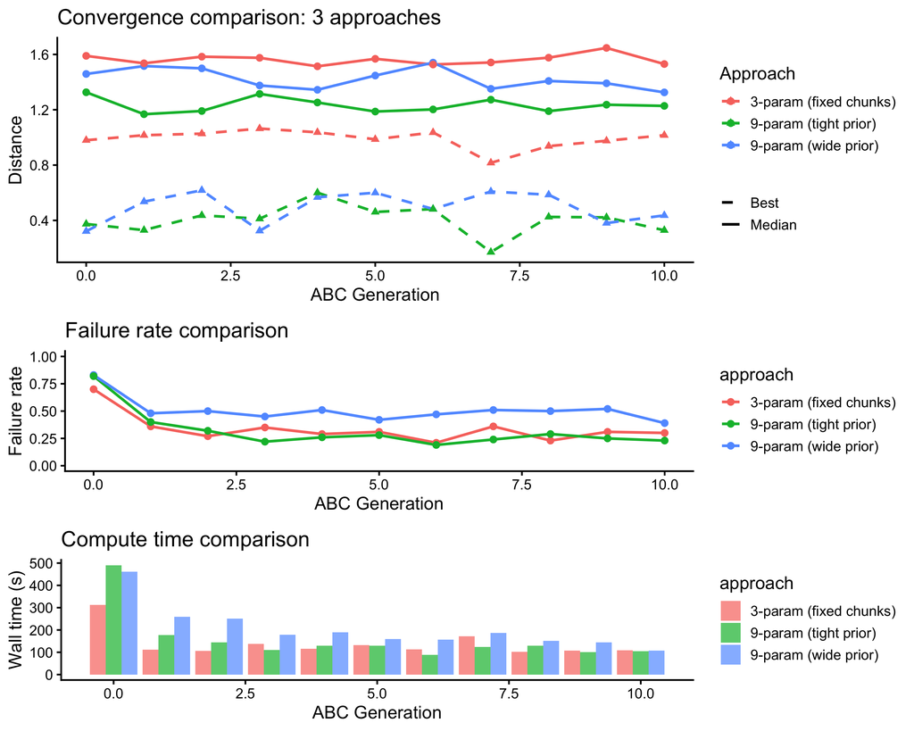

```r
# Combine convergence data
conv_all <- rbind(
  if (nrow(convergence_abc) > 0) convergence_abc[, .(gen, best, median, failure_rate, elapsed, approach = "9-param (wide prior)")] else NULL,
  if (nrow(convergence_3) > 0) convergence_3[, .(gen, best, median, failure_rate, elapsed, approach = "3-param (fixed chunks)")] else NULL,
  if (nrow(convergence_tight) > 0) convergence_tight[, .(gen, best, median, failure_rate, elapsed, approach = "9-param (tight prior)")] else NULL
)

if (nrow(conv_all) > 0) {
  p1 <- ggplot(conv_all, aes(x = gen, color = approach)) +
    geom_line(aes(y = median, linetype = "Median"), linewidth = 1) +
    geom_line(aes(y = best, linetype = "Best"), linewidth = 1) +
    geom_point(aes(y = median), size = 2) +
    geom_point(aes(y = best), size = 2, shape = 17) +
    theme_classic(base_size = 14) +
    scale_linetype_manual(values = c("Median" = "solid", "Best" = "dashed")) +
    labs(x = "ABC Generation", y = "Distance", color = "Approach",
         linetype = NULL,
         title = "Convergence comparison: 3 approaches")

  p2 <- ggplot(conv_all, aes(x = gen, y = failure_rate, color = approach)) +
    geom_line(linewidth = 1) + geom_point(size = 2) +
    theme_classic(base_size = 14) +
    labs(x = "ABC Generation", y = "Failure rate",
         title = "Failure rate comparison") +
    ylim(0, 1)

  p3 <- ggplot(conv_all, aes(x = gen, y = elapsed, fill = approach)) +
    geom_bar(stat = "identity", position = "dodge", alpha = 0.7) +
    theme_classic(base_size = 14) +
    labs(x = "ABC Generation", y = "Wall time (s)",
         title = "Compute time comparison")

  plot_grid(p1, p2, p3, ncol = 1, rel_heights = c(1.2, 0.8, 0.8))
}
```

```r
if (nrow(conv_all) > 0) {
  summary_compare <- conv_all[, .(
    final_best = round(last(best), 3),
    final_median = round(last(median), 3),
    mean_fail_rate = round(mean(failure_rate), 2),
    total_time = sum(elapsed),
    n_gens = .N
  ), by = approach]
  knitr::kable(summary_compare, caption = "Approach comparison summary")
}
```

Approach comparison summary

| approach | final_best | final_median | mean_fail_rate | total_time | n_gens |
| --- | --- | --- | --- | --- | --- |
| 9-param (wide prior) | 0.436 | 1.326 | 0.51 | 2246 | 11 |
| 3-param (fixed chunks) | 1.016 | 1.530 | 0.34 | 1519 | 11 |
| 9-param (tight prior) | 0.329 | 1.228 | 0.32 | 1728 | 11 |

## 4.4 Higher Compression Test

What if we use 2000x compression (500 sim gens instead of 1000)?

```r
# Test baseline params with different compression levels
compressions <- c(500, 1000, 2000, 5000)
comp_results <- list()

for (comp in compressions) {
  cat("Testing compression =", comp, "\n")
  mu_c <- MU_REAL * comp
  gens_c <- round(10e6 / 10 / comp)

  params <- BASELINE
  res <- tryCatch({
    setTimeLimit(elapsed = 60, transient = TRUE)
    sim <- suppressWarnings(run_sim_ps(
      max_units = HARD_CAP, max_t = gens_c, hard_cap = HARD_CAP,
      init_l = INIT_L, init_k0 = INIT_K0,
      p_local_dup = params$p_local_dup,
      p_distal_dup = params$p_distal_dup,
      p_del_chunk = params$p_del_chunk,
      mu_total = mu_c,
      local_dist = list(type="gamma", shape=params$local_shape, scale=params$local_scale),
      distal_dist = list(type="gamma", shape=params$distal_shape, scale=params$distal_scale),
      del_dist = list(type="gamma", shape=params$del_shape, scale=params$del_scale),
      verbose = FALSE, compute_pairs = FALSE
    ))
    setTimeLimit(elapsed = Inf, transient = TRUE)
    data.table(compression = comp, sim_gens = gens_c,
               n_units = nrow(sim$monomers),
               time_s = NA_real_,
               status = "ok")
  }, error = function(e) {
    setTimeLimit(elapsed = Inf, transient = TRUE)
    data.table(compression = comp, sim_gens = gens_c,
               n_units = NA, time_s = NA, status = "error")
  })
  comp_results[[length(comp_results) + 1]] <- res
}
```

```
#> Testing compression = 500
#> Testing compression = 1000
#> Testing compression = 2000
#> Testing compression = 5000
```

```r
comp_dt <- rbindlist(comp_results)
knitr::kable(comp_dt, caption = "Effect of compression on array size (baseline params)")
```

Effect of compression on array size (baseline params)

| compression | sim_gens | n_units | time_s | status |
| --- | --- | --- | --- | --- |
| 500 | 2000 | 60955 | NA | ok |
| 1000 | 1000 | 60203 | NA | ok |
| 2000 | 500 | 60091 | NA | ok |
| 5000 | 200 | 1081 | NA | ok |

Note: Higher compression means fewer generations, so rates per-generation must increase proportionally to maintain the same mu*t product. The current setup already scales mu with compression but does NOT scale the duplication/deletion rates. This means higher compression = fewer structural events = smaller arrays with the same rate parameters. This is a potential issue.

# 5. Deep Diagnostics

## 5.1 Parameter Correlations in Successful Particles

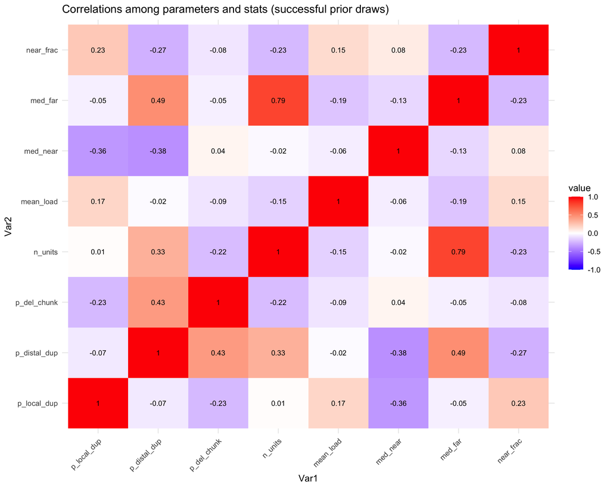

```r
# From the prior draws, look at correlations among successful particles
ok_prior <- prior_dt[status == "ok"]
if (nrow(ok_prior) > 5) {
  cor_vars <- c("p_local_dup", "p_distal_dup", "p_del_chunk",
                "n_units", "mean_load", "med_near", "med_far", "near_frac")
  cor_dt <- ok_prior[, ..cor_vars]

  # Correlation matrix
  cor_mat <- cor(cor_dt, use = "pairwise.complete.obs")

  # Simple heatmap using ggplot
  cor_melt <- as.data.table(reshape2::melt(cor_mat))
  ggplot(cor_melt, aes(x = Var1, y = Var2, fill = value)) +
    geom_tile() +
    geom_text(aes(label = round(value, 2)), size = 3) +
    scale_fill_gradient2(low = "blue", mid = "white", high = "red",
                         limits = c(-1, 1)) +
    theme_minimal(base_size = 11) +
    theme(axis.text.x = element_text(angle = 45, hjust = 1)) +
    labs(title = "Correlations among parameters and stats (successful prior draws)")
} else {
  cat("Not enough successful prior draws for correlation analysis\n")
}
```

## 5.2 The Explosive Growth Problem

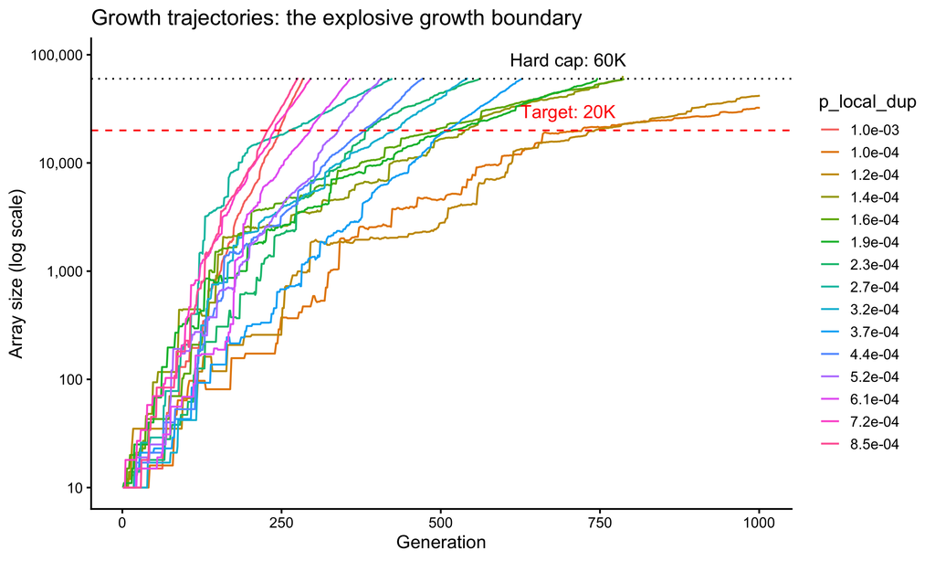

```r
# Run 20 sims with varying p_local_dup near the boundary and track L_vec
growth_p_values <- 10^seq(-4.0, -3.0, length.out = 15)
growth_traces <- list()

for (i in seq_along(growth_p_values)) {
  ploc <- growth_p_values[i]
  params <- BASELINE
  params$p_local_dup <- ploc

  sim <- tryCatch({
    setTimeLimit(elapsed = 30, transient = TRUE)
    suppressWarnings(run_sim_ps(
      max_units = HARD_CAP, max_t = SIM_GENS, hard_cap = HARD_CAP,
      init_l = INIT_L, init_k0 = INIT_K0,
      p_local_dup = params$p_local_dup,
      p_distal_dup = params$p_distal_dup,
      p_del_chunk = params$p_del_chunk,
      mu_total = MU_COMPRESSED,
      local_dist = list(type="gamma", shape=params$local_shape, scale=params$local_scale),
      distal_dist = list(type="gamma", shape=params$distal_shape, scale=params$distal_scale),
      del_dist = list(type="gamma", shape=params$del_shape, scale=params$del_scale),
      verbose = FALSE, compute_pairs = FALSE
    ))
  }, error = function(e) NULL,
  finally = setTimeLimit(elapsed = Inf, transient = TRUE))

  if (!is.null(sim)) {
    l_vec <- sim$L_vec
    # Subsample trajectory for plotting
    idx <- unique(c(seq(1, length(l_vec), length.out = min(500, length(l_vec))),
                    length(l_vec)))
    growth_traces[[i]] <- data.table(
      gen = idx,
      size = l_vec[idx],
      p_local = ploc,
      label = sprintf("%.1e", ploc)
    )
  }
}

growth_dt <- rbindlist(growth_traces)
if (nrow(growth_dt) > 0) {
  ggplot(growth_dt, aes(x = gen, y = size, color = label, group = label)) +
    geom_line(linewidth = 0.7) +
    geom_hline(yintercept = TARGET$target_array_size, color = "red",
               linetype = "dashed") +
    geom_hline(yintercept = HARD_CAP, color = "black", linetype = "dotted") +
    scale_y_log10(labels = scales::comma) +
    theme_classic(base_size = 14) +
    labs(x = "Generation", y = "Array size (log scale)",
         color = "p_local_dup",
         title = "Growth trajectories: the explosive growth boundary") +
    annotate("text", x = SIM_GENS * 0.7, y = TARGET$target_array_size * 1.5,
             label = "Target: 20K", color = "red") +
    annotate("text", x = SIM_GENS * 0.7, y = HARD_CAP * 1.5,
             label = "Hard cap: 60K", color = "black")
}
```